# MovieLens Project Question Notebook - Rough

### `Project - MovieLens Data Analysis`

The GroupLens Research Project is a research group in the Department of Computer Science and Engineering at the University of Minnesota. The data is widely used for collaborative filtering and other filtering solutions. However, we will be using this data to act as a means to demonstrate our skill in using Python to “play” with data.

### `Objective:`

- To implement the techniques learnt as a part of the course.

### `Datasets Information:`

*rating.csv:* It contains information on ratings given by the users to a particular movie.

- user id: id assigned to every user
- movie id: id assigned to every movie
- rating: rating given by the user
- timestamp: Time recorded when the user gave a rating

*movie.csv:* File contains information related to the movies and their genre.

- movie id: id assigned to every movie
- movie title: Title of the movie
- release date: Date of release of the movie
- Action: Genre containing binary values (1 - for action 0 - not action)
- Adventure: Genre containing binary values (1 - for adventure 0 - not adventure)
- Animation: Genre containing binary values (1 - for animation 0 - not animation)
- Children’s: Genre containing binary values (1 - for children's 0 - not children's)
- Comedy: Genre containing binary values (1 - for comedy 0 - not comedy)
- Crime: Genre containing binary values (1 - for crime 0 - not crime)
- Documentary: Genre containing binary values (1 - for documentary 0 - not documentary)
- Drama: Genre containing binary values (1 - for drama 0 - not drama)
- Fantasy: Genre containing binary values (1 - for fantasy 0 - not fantasy)
- Film-Noir: Genre containing binary values (1 - for film-noir 0 - not film-noir)
- Horror: Genre containing binary values (1 - for horror 0 - not horror)
- Musical: Genre containing binary values (1 - for musical 0 - not musical)
- Mystery: Genre containing binary values (1 - for mystery 0 - not mystery)
- Romance: Genre containing binary values (1 - for romance 0 - not romance)
- Sci-Fi: Genre containing binary values (1 - for sci-fi 0 - not sci-fi)
- Thriller: Genre containing binary values (1 - for thriller 0 - not thriller)
- War: Genre containing binary values (1 - for war 0 - not war)
- Western: Genre containing binary values (1 - for western - not western)

*user.csv:* It contains information of the users who have rated the movies.

- user id: id assigned to every user
- age: Age of the user
- gender: Gender of the user
- occupation: Occupation of the user
- zip code: Zip code of the use

**`Please provide your insights wherever necessary.`**

### `Learning Outcomes:`

- Exploratory Data Analysis
- Visualization using Python
- Pandas – groupby, merging

### `Domain`

- Internet and Entertainment

**Note that the project will need you to apply the concepts of groupby and merging extensively.**

### 1. Import the necessary packages - 2.5 marks

```python
import numpy as np
import pandas as pd
import matplotlib.pyplot as plt
import seaborn as sns
```

### 2. Read the 3 datasets into dataframes - 2.5 marks

```python
Data  = pd.read_csv('Data.csv')
item  = pd.read_csv('item.csv')
user  = pd.read_csv('user.csv')
```

### 3. Apply info, shape, describe, and find the number of missing values in the data. Present at least 3 observations from these operations - 2.5 marks

- Note that you will need to do it for all the three datasets seperately

```python
Data.info()
print("\n")
user.info()
print("\n")
item.info()

print('\n\nData Shape', Data.shape)
print('Movie Shape', item.shape)
print('User Shape', user.shape)

#Please turn to next cell
```

```
<class 'pandas.core.frame.DataFrame'>
RangeIndex: 100000 entries, 0 to 99999
Data columns (total 4 columns):
 #   Column     Non-Null Count   Dtype
---  ------     --------------   -----
 0   user id    100000 non-null  int64
 1   movie id   100000 non-null  int64
 2   rating     100000 non-null  int64
 3   timestamp  100000 non-null  int64
dtypes: int64(4)
memory usage: 3.1 MB


<class 'pandas.core.frame.DataFrame'>
RangeIndex: 943 entries, 0 to 942
Data columns (total 5 columns):
 #   Column      Non-Null Count  Dtype
---  ------      --------------  -----
 0   user id     943 non-null    int64
 1   age         943 non-null    int64
 2   gender      943 non-null    object
 3   occupation  943 non-null    object
 4   zip code    943 non-null    object
dtypes: int64(2), object(3)
memory usage: 37.0+ KB


<class 'pandas.core.frame.DataFrame'>
RangeIndex: 1681 entries, 0 to 1680
Data columns (total 22 columns):
 #   Column        Non-Null Count  Dtype
---  ------        --------------  -----
 0   movie id      1681 non-null   int64
 1   movie title   1681 non-null   object
 2   release date  1681 non-null   object
 3   unknown       1681 non-null   int64
 4   Action        1681 non-null   int64
 5   Adventure     1681 non-null   int64
 6   Animation     1681 non-null   int64
 7   Childrens     1681 non-null   int64
 8   Comedy        1681 non-null   int64
 9   Crime         1681 non-null   int64
 10  Documentary   1681 non-null   int64
 11  Drama         1681 non-null   int64
 12  Fantasy       1681 non-null   int64
 13  Film-Noir     1681 non-null   int64
 14  Horror        1681 non-null   int64
 15  Musical       1681 non-null   int64
 16  Mystery       1681 non-null   int64
 17  Romance       1681 non-null   int64
 18  Sci-Fi        1681 non-null   int64
 19  Thriller      1681 non-null   int64
 20  War           1681 non-null   int64
 21  Western       1681 non-null   int64
dtypes: int64(20), object(2)
memory usage: 289.0+ KB


Data Shape (100000, 4)
Movie Shape (1681, 22)
User Shape (943, 5)
```

```python
Data.describe()
```

|  | user id | movie id | rating | timestamp |
| --- | --- | --- | --- | --- |
| count | 100000.00000 | 100000.000000 | 100000.000000 | 1.000000e+05 |
| mean | 462.48475 | 425.530130 | 3.529860 | 8.835289e+08 |
| std | 266.61442 | 330.798356 | 1.125674 | 5.343856e+06 |
| min | 1.00000 | 1.000000 | 1.000000 | 8.747247e+08 |
| 25% | 254.00000 | 175.000000 | 3.000000 | 8.794487e+08 |
| 50% | 447.00000 | 322.000000 | 4.000000 | 8.828269e+08 |
| 75% | 682.00000 | 631.000000 | 4.000000 | 8.882600e+08 |
| max | 943.00000 | 1682.000000 | 5.000000 | 8.932866e+08 |

```python
user.describe()
```

|  | user id | age |
| --- | --- | --- |
| count | 943.000000 | 943.000000 |
| mean | 472.000000 | 34.051962 |
| std | 272.364951 | 12.192740 |
| min | 1.000000 | 7.000000 |
| 25% | 236.500000 | 25.000000 |
| 50% | 472.000000 | 31.000000 |
| 75% | 707.500000 | 43.000000 |
| max | 943.000000 | 73.000000 |

```python
item.describe().T
```

|  | count | mean | std | min | 25% | 50% | 75% | max |
| --- | --- | --- | --- | --- | --- | --- | --- | --- |
| movie id | 1681.0 | 841.841761 | 485.638077 | 1.0 | 422.0 | 842.0 | 1262.0 | 1682.0 |
| unknown | 1681.0 | 0.000595 | 0.024390 | 0.0 | 0.0 | 0.0 | 0.0 | 1.0 |
| Action | 1681.0 | 0.149316 | 0.356506 | 0.0 | 0.0 | 0.0 | 0.0 | 1.0 |
| Adventure | 1681.0 | 0.080309 | 0.271852 | 0.0 | 0.0 | 0.0 | 0.0 | 1.0 |
| Animation | 1681.0 | 0.024985 | 0.156126 | 0.0 | 0.0 | 0.0 | 0.0 | 1.0 |
| Childrens | 1681.0 | 0.072576 | 0.259516 | 0.0 | 0.0 | 0.0 | 0.0 | 1.0 |
| Comedy | 1681.0 | 0.300416 | 0.458576 | 0.0 | 0.0 | 0.0 | 1.0 | 1.0 |
| Crime | 1681.0 | 0.064842 | 0.246321 | 0.0 | 0.0 | 0.0 | 0.0 | 1.0 |
| Documentary | 1681.0 | 0.029744 | 0.169931 | 0.0 | 0.0 | 0.0 | 0.0 | 1.0 |
| Drama | 1681.0 | 0.431291 | 0.495404 | 0.0 | 0.0 | 0.0 | 1.0 | 1.0 |
| Fantasy | 1681.0 | 0.013087 | 0.113683 | 0.0 | 0.0 | 0.0 | 0.0 | 1.0 |
| Film-Noir | 1681.0 | 0.014277 | 0.118667 | 0.0 | 0.0 | 0.0 | 0.0 | 1.0 |
| Horror | 1681.0 | 0.054729 | 0.227519 | 0.0 | 0.0 | 0.0 | 0.0 | 1.0 |
| Musical | 1681.0 | 0.033314 | 0.179507 | 0.0 | 0.0 | 0.0 | 0.0 | 1.0 |
| Mystery | 1681.0 | 0.036288 | 0.187061 | 0.0 | 0.0 | 0.0 | 0.0 | 1.0 |
| Romance | 1681.0 | 0.146936 | 0.354148 | 0.0 | 0.0 | 0.0 | 0.0 | 1.0 |
| Sci-Fi | 1681.0 | 0.060083 | 0.237712 | 0.0 | 0.0 | 0.0 | 0.0 | 1.0 |
| Thriller | 1681.0 | 0.149316 | 0.356506 | 0.0 | 0.0 | 0.0 | 0.0 | 1.0 |
| War | 1681.0 | 0.042237 | 0.201189 | 0.0 | 0.0 | 0.0 | 0.0 | 1.0 |
| Western | 1681.0 | 0.016062 | 0.125751 | 0.0 | 0.0 | 0.0 | 0.0 | 1.0 |

```python
#Find the number of missing values
print("Number of missing values in 'Data' dataframe: "+ str(Data.isnull().sum().sum()))
print("Number of missing values in 'User' dataframe: "+ str(user.isnull().sum().sum()))
print("Number of missing values in 'Item' dataframe: "+ str(item.isnull().sum().sum()))
```

```
Number of missing values in 'Data' dataframe: 0
Number of missing values in 'User' dataframe: 0
Number of missing values in 'Item' dataframe: 0
```

**Observations:**

**Common observation for all dataframes:** No Missing values observed. Since there are no missing values at dataframe level, further drill down to check missing values at Series (column) level is not performed {e.g. data.isnull().sum()}

**Observations for "Data":**

1. Data comprises of 100,000 ratings given by audience.
2. All data are of integer type (int64). Memory used is 3.1 MB.
3. Timestamp is stored as a 9-digit numeric value (Probably as Unix epoch time).
4. Ratings look like whole numbers. They are probably given as stars as no floating (double) values were observed.
5. Median (50%) of ratings is 4, meaning that more than 50% movies received rating 4 and above.

**Observations for "User":**

1. Memory used is around 38 KB.
2. Age ranges from 7 to 73. Mean is greater than Median for age. Upper quartile is 43 and max is 73. So 73 is an outlier. It is right skewed.
3. Audience appears to be a mix of males and females comprising of people different age groups.
4. Categorical data (Gender, ZipCode and Occupation) may help to analyse the preferences of specific audience for specific movie genres. Also, it can help to analyse the occupations available in a particular area, and their gender ratio.

**Observations for "item":**

1. There are 22 columns in the dataframe, including 19 columns indicating genre names.
2. Memory used is around 290 KB
3. Only for genre Comedy and Drama, 75% = 1. This means that there are more than 25% (421 or more movies, total count being 1681) that are categorized as Comedy. Similarly, there are 421 or more movies that have been categorized as Drama. In both categories the total number of movies should be less than 50% of total count, i.e. 841. Also, for these two Genres, standard deviation is around 0.5
4. For remaining all genres, 25%, 50% and 75% are 0. This means that less than 421 movies are in each of these genres.
5. Standard deviation for unknown genre is very low, which probably means that number of obserations in this category are low.

### 4. Find the number of movies per genre using the item data - 2.5 marks

```python
#your code here
item.drop(['movie id', 'release date','movie title'], axis=1, inplace=False).sum()
```

```
unknown          1
Action         251
Adventure      135
Animation       42
Childrens      122
Comedy         505
Crime          109
Documentary     50
Drama          725
Fantasy         22
Film-Noir       24
Horror          92
Musical         56
Mystery         61
Romance        247
Sci-Fi         101
Thriller       251
War             71
Western         27
dtype: int64
```

**Insights:**

1. Drama has the highest number of movies followed by comedy, which indicates that they are amongst the most preferred genres.
2. Fantasy, Film-Noir, and Western are amongst the least preferred genres.
3. Unknown has only one movie, it may be dropped from further analysis.
4. Action and Thriller have the same number of movies. So it may be further investigated that if same movies are categorized as Action and Thriller both to avoid redundancy in data.

### 5. Drop the movie where the genre is unknown - 2.5 marks

```python
#your code here
#item  = pd.read_csv('item.csv') #--> Use this statement if this cell needs to be reexecuted after Series "Unknown" is dropped

#Step1: Find movie where Genre is unknown. Check if the same movie is under any other Genre also.
print(item["movie id"][item["unknown"] == 1])

#Movie ID comes as 1373. It's not present under any other genre. So the row can be dropped

#Step2: Impact reduction: Drop the corresponding row from "Data" dataframe as the movie is not present in any other genre.
Data = Data[Data["movie id"] != 1373]

#Step3: Drop Unknown genre. This can be done by first dropping rows having unknown = 1 and then by dropping column altogether
item = item[item["unknown"] != 1]
item.drop('unknown', axis=1, inplace=True)
```

```
1371    1373
Name: movie id, dtype: int64
```

**Insights:**

**Step1**: Find movie where Genre is unknown. Check if the same movie is under other Genre also. Movie ID comes as 1373. It's not present under any other genre.

**Step2**: Impact reduction. Drop the corresponding row from "Data" dataframe as the movie is not present in any other genre. Even if the step is not performed, these records will still be removed if "Data" dataframe is merged with "item" dataframe using inner join.

**Step3**: Drop Unknown genre. This can be done by first dropping rows having unknown = 1 and then by dropping column altogether. Dropping rows should not be done if the movie belongs to any other genre than unknown.

### 6. Find the movies that have more than one genre - 5 marks

hint: use sum on the axis = 1

Display movie name, number of genres for the movie in dataframe

and also print(total number of movies which have more than one genres)

```python
#your code here
#Set the following option to ensure that all the data is displayed.
#Note that this option is commented before generating HTML file.
#pd.set_option('display.max_rows', 1700)

#Step1: If the Series 'movie id' is not dropped from the dataframe, it's value affects the sum function used in Step2.
#To avoid impact of dropping "movie id" on actual data, create a new frame with desired Series.
movie_count = item.drop('movie id', axis=1, inplace=False)

#Step2: Create a new series containing number of genres
movie_count["number of genres"] = movie_count.sum(axis = 1)

#Step3: Print movie title and number of genres
print(movie_count[["movie title","number of genres"]])

#Step4: Print number of movies where the same movie is present in more than one genres.
cnt = movie_count[["number of genres"]][movie_count["number of genres"]>1].count()
#This returns a series with number of movies tagged to more than one genre
print("\nNumber of movies that have been tagged to more than one genre is: " + str(cnt[0]))

#Step5: Optional: Print movie title and number of genres where the same movie is present in more than one genres.
#print("\n\n")
#print(movie_count[["movie title","number of genres"]][movie_count["number of genres"]>1])
```

```
                              movie title  number of genres
0                              Toy Story                  3
1                              GoldenEye                  3
2                             Four Rooms                  1
3                             Get Shorty                  3
4                                Copycat                  3
...                                   ...               ...
1676                          Mat' i syn                  1
1677                           B. Monkey                  2
1678                       Sliding Doors                  2
1679                        You So Crazy                  1
1680  Scream of Stone (Schrei aus Stein)                  1

[1680 rows x 2 columns]

Number of movies that have been tagged to more than one genre is: 849
```

**Insights:**

1. There are 849 movies which are present in more than one genre.
2. 3 movies categorized with 6 genre (maximum number of genres)
3. 11 movies categorized with 5 genre
4. "movie id" is an integer which impacts the calculation of 'number of genres' in which a movie is present. Therefore, it was dropped first.

```python
#Ask this question: What's the reason for the following behaviour
#print(movie_count[["movie title","number of genres"]].max() # It gives one movie with 6 genres
#print(movie_count[["movie title","number of genres"]][movie_count["number of genres"]==6])
# Above statement gives 3 movies with 6 genres, excluding the movie given by max()
```

### 7. Univariate plots of columns: 'rating', 'Age', 'release year', 'Gender' and 'Occupation' - 10 marks

*HINT: Use distplot for age and countplot for release year, ratings,*

*HINT: Please refer to the below snippet to understand how to get to release year from release date. You can use str.split() as depicted below or you could convert it to pandas datetime format and extract year (.dt.year)*

```python
a = 'My*cat*is*brown'
print(a.split('*')[3])

#similarly, the release year needs to be taken out from release date

#also you can simply slice existing string to get the desired data, if we want to take out the colour of the cat

print(a[10:])
print(a[-5:])
```

```
brown
brown
brown
```

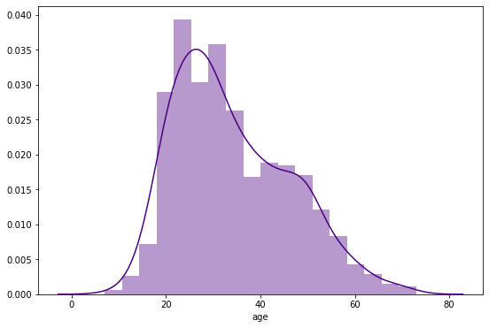

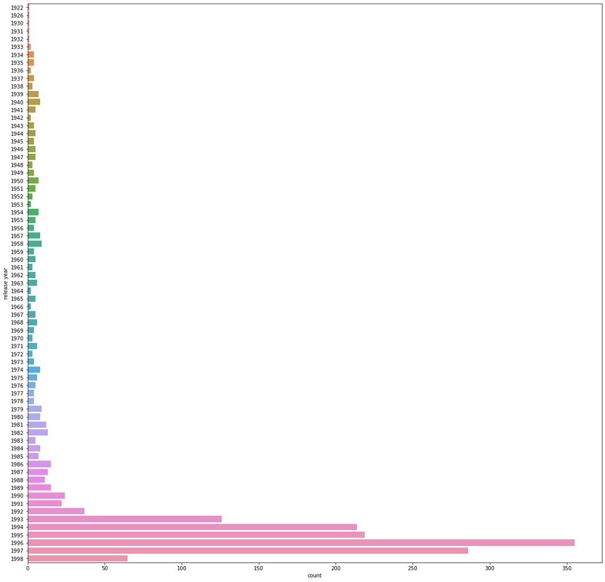

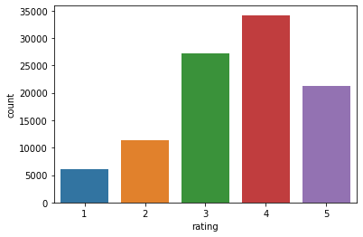

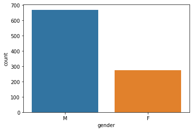

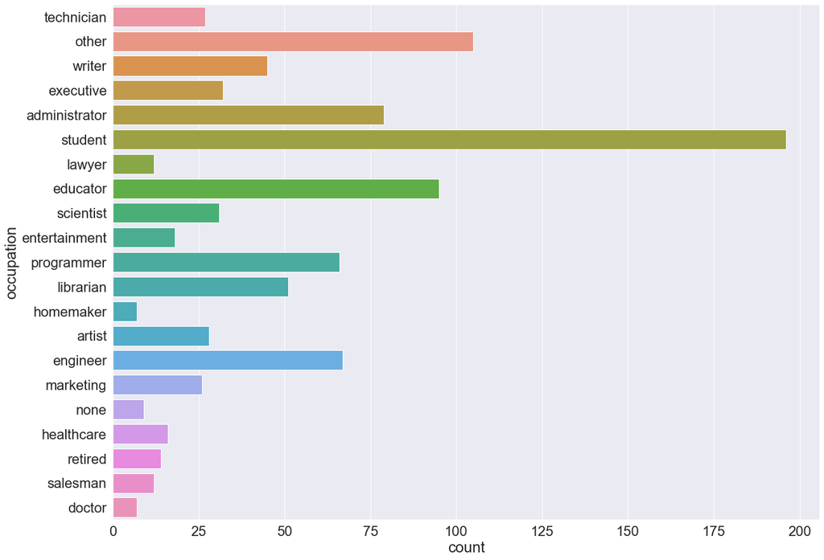

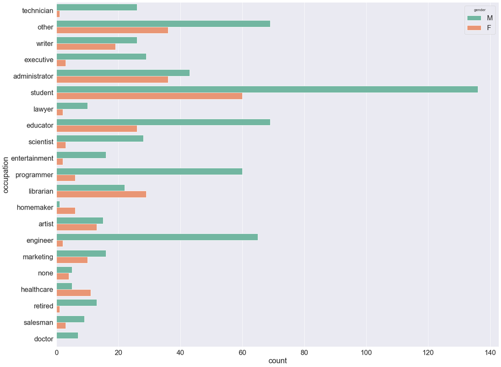

```python
#your code here

#Step1: Create a function to extract "release year" from "release date"
def extract_year(a):
    return a.split('-')[2]

#Step2: apply the function "extract_year" on Series "release date" of dataframe item.
#This results in a series. Add this Series to item dataframe for future references.
item["release year"] = item["release date"].apply(extract_year)

#Step3: plot graphs
#Age
plt.figure (figsize = (9,6))
sns.distplot(user['age'], kde=True, color = 'indigo')
plt.show()

#Release Year
plt.figure (figsize = (20,20))
sns.countplot(y=item["release year"], data=item);
plt.show()

#Rating
sns.countplot(Data['rating']);
plt.show()

#Gender
sns.countplot(user['gender']);
plt.show()

#Occupation
plt.figure (figsize = (20,15))
sns.set(font_scale=2)
sns.countplot(y=user['occupation'], data=user);
plt.show()

#Gender And Occupation
plt.figure (figsize = (25,20))
sns.set(font_scale=2)
sns.countplot(y='occupation', data=user, hue = 'gender', palette='Set2')
plt.show()
```

### 8. Visualize how popularity of genres has changed over the years - 10 marks

Note that you need to use the **percent of number of releases in a year** as a parameter of popularity of a genre

Hint 1: You need to reach to a data frame where the release year is the index and the genre is the column names (one cell shows the number of release in a year in one genre) or vice versa. (Drop unnecessary column if there are any)

Hint 2: Find the total number of movies release in a year(use item dataset to get count of movies released in a particular year, store that value in a new column as 'total'). Now divide the value of each genre in that year by total to get percentage number of release in a particular year. `(df.div(df['total'], axis= 0) * 100)`

Once that is achieved, you can either use univariate plots or can use the heatmap to visualise all the changes over the years in one go.

Hint 3: Use groupby on the relevant column and use sum() on the same to find out the number of releases in a year/genre.

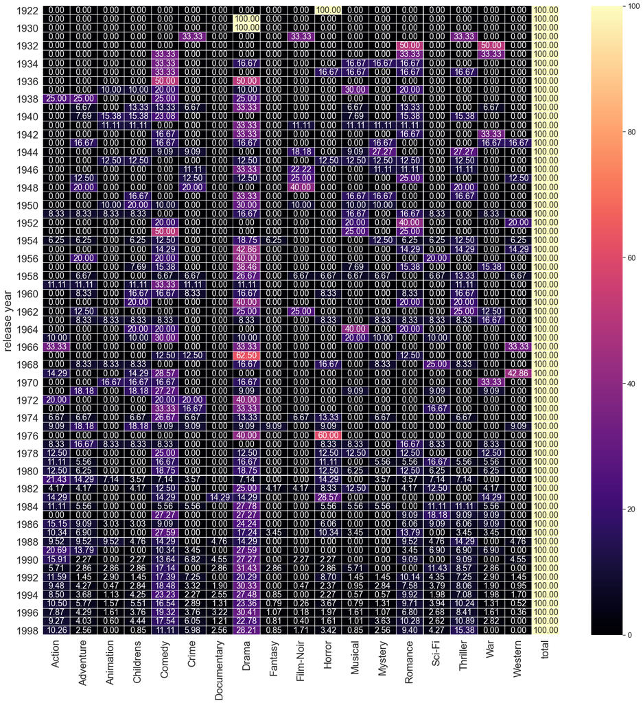

```python
#your code here
item_yr_genre = item.drop(['movie id','movie title','release date'], axis=1, inplace=False)
new_dataset = item_yr_genre.groupby("release year").sum()
new_dataset['total']= new_dataset.iloc[:, 0:].sum(axis=1)
new_dataset_per = new_dataset.div(new_dataset['total'], axis= 0) * 100

fig,ax = plt.subplots(figsize=(25, 25))
sns.set(font_scale=1.5)
sns.heatmap(new_dataset_per, annot=True, linewidths=0.05, fmt= '.2f',cmap="magma") # the color intensity is based on
plt.show()
```

**Insights:**

### 9. Find the top 25 movies in terms of average ratings for movies that have been rated more than 100 times - 10 marks

Hints :

1. Find the count of ratings and average ratings for every movie.
2. Slice the movies which have ratings more than 100.
3. Sort values according to average rating such that movie which highest rating is on top.
4. Select top 25 movies.
5. You will have to use the .merge() function to get the movie titles.

Note: This question will need you to research about groupby and apply your findings. You can find more on groupby on https://realpython.com/pandas-groupby/.

```python
#your code here

#Step1: Drop unnecessary columns, and to avoid impact on the original dataframe, create a new dataframe with desired data
movie_rating_df = Data.drop(['user id','timestamp'], axis=1, inplace=False)
#movie_rating_df.head()

#Step2: Count number of times a movie has been rated. Save grouped data into a dataframe
rating_count = movie_rating_df.groupby("movie id").count()

#Step3: Take the sum of all the ratings for each movie
rating_avg =  movie_rating_df.groupby("movie id").sum()

#Step4: Merge the dataframes obtained in step2 and step3
rating_count_avg = pd.merge(rating_count,rating_avg,how='inner',on='movie id')

#Step5: Calculate average.
rating_count_avg["average rating"]=rating_count_avg["rating_y"] / rating_count_avg["rating_x"]

#Step6: Slice above dataframe to obtain movies that have been rated more than 100 times
rating_count_avg = rating_count_avg[rating_count_avg["rating_x"] > 100]

#Step7: Sort above dataframe according to "average rating" in descending order
rating_count_avg.sort_values(by="average rating",ascending=False,inplace=True)

#Step8: Get movie names
rating_count_avg = pd.merge(rating_count_avg,item,how='inner',on='movie id').round(2)

#Step9: Display top 25 movies
# Set following option to ensure that full movie title is diplayed.
pd.set_option('max_colwidth', 400)
rating_count_avg[["movie title", "average rating"]].iloc[:25,:]
```

|  | movie title | average rating |
| --- | --- | --- |
| 0 | Close Shave, A | 4.49 |
| 1 | Schindler's List | 4.47 |
| 2 | Wrong Trousers, The | 4.47 |
| 3 | Casablanca | 4.46 |
| 4 | Shawshank Redemption, The | 4.45 |
| 5 | Rear Window | 4.39 |
| 6 | Usual Suspects, The | 4.39 |
| 7 | Star Wars | 4.36 |
| 8 | 12 Angry Men | 4.34 |
| 9 | Citizen Kane | 4.29 |
| 10 | To Kill a Mockingbird | 4.29 |
| 11 | One Flew Over the Cuckoo's Nest | 4.29 |
| 12 | Silence of the Lambs, The | 4.29 |
| 13 | North by Northwest | 4.28 |
| 14 | Godfather, The | 4.28 |
| 15 | Secrets & Lies | 4.27 |
| 16 | Good Will Hunting | 4.26 |
| 17 | Manchurian Candidate, The | 4.26 |
| 18 | Dr. Strangelove or: How I Learned to Stop Worrying and Love the Bomb | 4.25 |
| 19 | Raiders of the Lost Ark | 4.25 |
| 20 | Vertigo | 4.25 |
| 21 | Titanic | 4.25 |
| 22 | Lawrence of Arabia | 4.23 |
| 23 | Maltese Falcon, The | 4.21 |
| 24 | Empire Strikes Back, The | 4.20 |

### 10. Check for the validity of the below statements with respect to the data provided - 10 marks

- Men watch more drama than women
- Women watch more Sci-Fi than men
- Men watch more Romance than women

**compare the percentages**

**Please pay attention to what should be the denominator while calculating percentages**

1. Merge all the datasets
2. There is no need to conduct statistical tests around this. Just **compare the percentages** and comment on the validity of the above statements.
3. you might want ot use the .sum(), .div() function here.
4. Use number of ratings to validate the numbers. For example, if out of 4000 ratings received by women, 3000 are for drama, we will assume that 75% of the women watch drama.

```python
#your code here

#Step1: Merge Data with item to form a new dataframe Data_item. Use inner join to ensure maximum data accuracy.
Data_item = pd.merge(Data,item,how='inner',on='movie id')

#Step1: Merge Data_item with user to form a new dataframe Data_item_user. Use inner join to ensure maximum data accuracy.
Data_item_user = pd.merge(Data_item,user,how='inner',on='user id')

#Step3: Calculate total number of males and females in the dataset
cnt_g = (Data_item_user.groupby(["gender"])["gender"].count()).rename("Total")
#print(cnt_g)

#Step3: Calculate total number of males and females who rated movies in genre "Sci-Fi"
cnt_sci = (Data_item_user[Data_item_user["Sci-Fi"] == 1].groupby(["gender"])["gender"].count()).rename("SCI-FI")
#print(cnt_sci)

#Step4: Calculate total number of males and females who rated movies in genre "Romance"
cnt_rom = (Data_item_user[Data_item_user["Romance"] == 1].groupby(["gender"])["gender"].count()).rename("Romance")
#print(cnt_rom)

#Step5: Calculate total number of males and females who rated movies in genre "Drama"
cnt_dr = (Data_item_user[Data_item_user["Drama"] == 1].groupby(["gender"])["gender"].count()).rename("Drama")
#print(cnt_dr)

#Step6: Concatenate all the series obtained from steps 3-5 into a single dataframe
all_counts=pd.concat([cnt_g,cnt_sci,cnt_rom,cnt_dr],axis = 1, sort=True)

#Step7: Calculate %
all_counts['SCI-FI %']=all_counts["SCI-FI"]/all_counts["Total"]*100
all_counts['Romance %']=all_counts["Romance"]/all_counts["Total"]*100
all_counts['Drama %']=all_counts["Drama"]/all_counts["Total"]*100

#Step8: Display resultant dataframe and verify the statements
all_counts
```

| gender | Total | SCI-FI | Romance | Drama | SCI-FI % | Romance % | Drama % |
| --- | --- | --- | --- | --- | --- | --- | --- |
| F | 25738 | 2629 | 5858 | 11008 | 10.214469 | 22.760121 | 42.769446 |
| M | 74252 | 10101 | 13603 | 28887 | 13.603674 | 18.320045 | 38.904003 |

**Conclusion:**

1. Men watch more drama than women --> False
2. Women watch more Sci-Fi than men --> False
3. Men watch more Romance than women --> False